# POWER (in the statistical sense)

Laurel Brehm

# What is power?

Let’s start out with some nuts and bolts!

# NHST

We are working under the null hypothesis significance testing framework = the type of stats most commonly taught in most places. (this is one of those terms that doesn’t have a super obvious Bayesian analogue)

H0 is our null hypothesis. For example…

- H0 = stats are boring
- H1 = stats are not boring

# NHST

In NHST, we assess whether data are covered under the null hypothesis, and try to reject it if we can.

We do so by looking at whether the data are likely under the null hypothesis

- p-value = how likely is it that these data are true, given H0

The typical threshold that is set is p < 0.05

- A value with p < 0.05 is a ‘significant’ value
- p < 0.05 = an outcome unlikely under the null hypothesis.

# Type I error

An outcome unlikely under the null hypothesis is still *possible*

In fact, it occurs alpha ($\alpha$)% of the time – 5% of cases!

- Type I error – a false positive (‘I found it’ error)

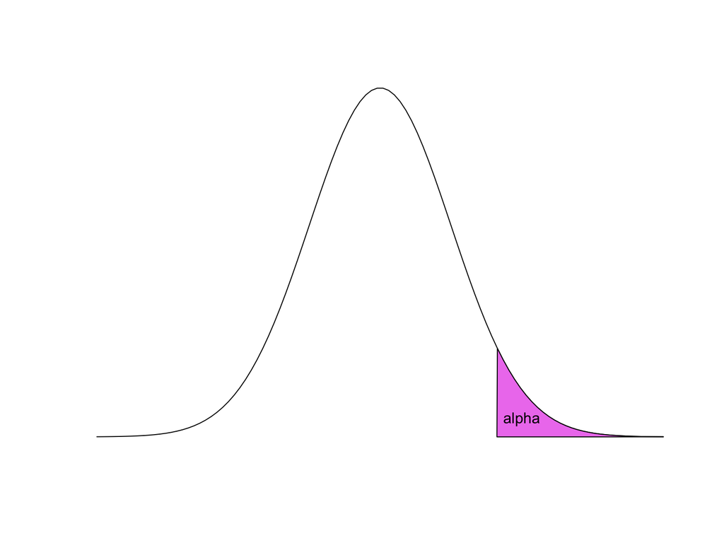

# Beta

But we actually care about H1 – the alternate hypothesis.

Comparing the distributions gives us beta ($\beta$) = the amount of the H1 curve below the $\alpha$ threshold.

This is when we fail to reject H0 when in fact, H1 is true.

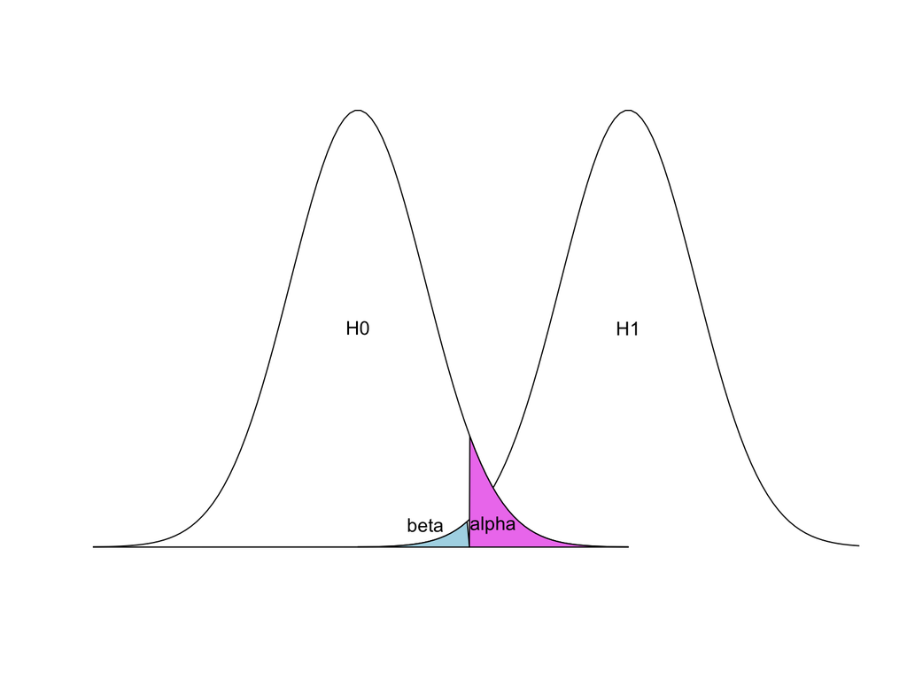

# Bad betas and betta betas

$\beta$ is the false negative rate (type II or “2 bad ya missed it” error).

If H0 and H1 are very different, $\beta$ will be small = few false negatives.

If H0 and H1 are very similar, $\beta$ will be large = many false negatives.

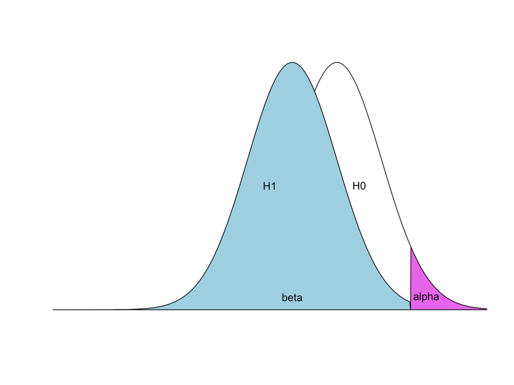

# Power is 1 - Beta

Power is mathematically defined as 1-$\beta$.

It is the ability to correctly reject H0, the null hypothesis = to find the truth!

Maximise power by minimising false negatives.

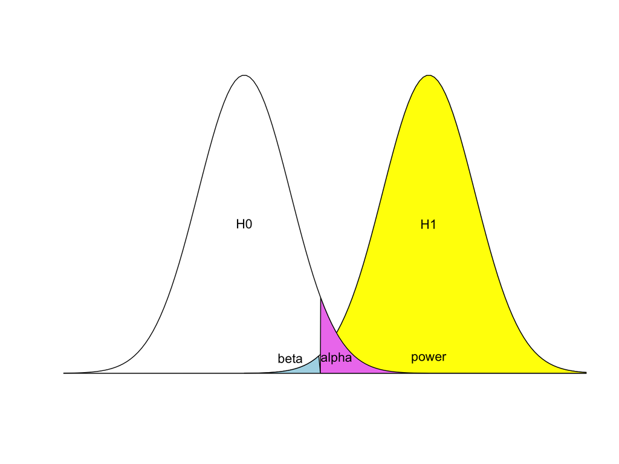

# Sample size and variability

Power relates to sample size because sampling is variable.

With small sample size, the estimate of the H1 mean is not very precise.

Look at how the mean (heavy line) bounces around… This could over-inflate our power estimate.

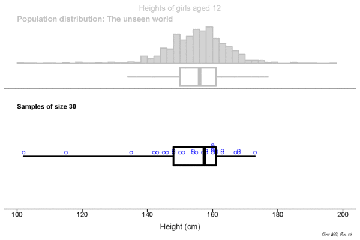

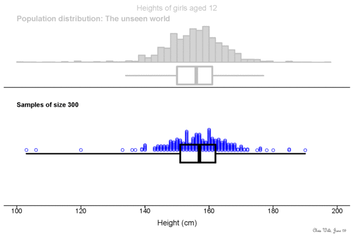

https://www.stat.auckland.ac.nz/~wild/WPRH/

# Sample size and variability

With small samples, the estimate of the H1 error is also less precise.

Look at how the rectangle (interquartile interval) changes in size more on the left… This decreases power.

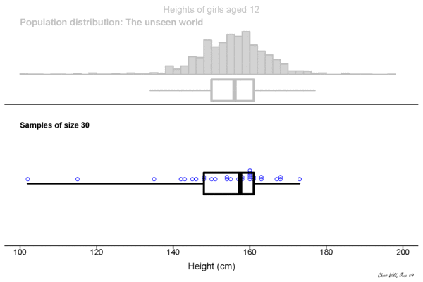

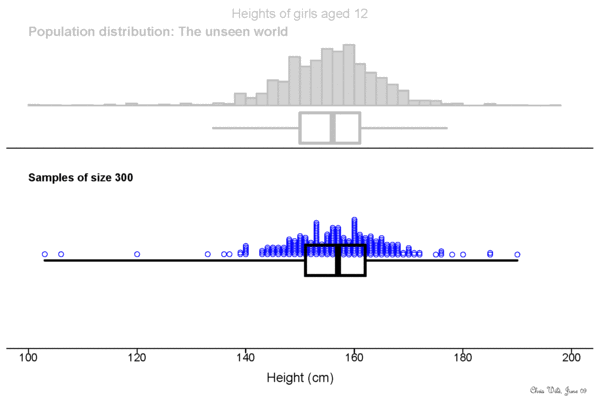

https://www.stat.auckland.ac.nz/~wild/WPRH/

# Maximising power

# How to power?

1. Functions that other people have made in R or Julia:

in R, these are:

- G*Power
- simr

in Julia:

- various functions that Lisa DeBruine has written: https://debruine.github.io/
2. simulations (can be run in whatever language– stay tuned for part 2)
3. Look up power tables based on effect size and study design:

e.g. https://pubmed.ncbi.nlm.nih.gov/25111580/

4. pragmatic restrictions: what do you have capacity to test?